# Statistical Analysis HW2

2023-10-18

## Question 2

Let 𝑋 ∼ 𝑁(1, 2). Compute the probability 𝑃(3 < 𝑋 < 4). (Hint: 𝑃(𝑎 < 𝑋 < 𝑏) = 𝑃(𝑋 < 𝑏) −𝑃(𝑋 < 𝑎)

```r
mu <- 1
sigma <- sqrt(2)
pnorm(4, mean=mu, sd=sigma) - pnorm(3, mean=mu, sd=sigma)
```

```
## [1] 0.06170218
```

## Question 3

Right Tail Probability: Let 𝑋 ∼ 𝒳^2 𝑘=10 be a chi-squared random variable with 𝑘 = 10 degrees of freedom.  
Compute the probability 𝑃(𝑋 > 20) in two ways:

1. Use the fact that 𝑃(𝑋 > 𝑥) = 1 −𝑃(𝑋 ≤ 𝑥)
2. Override the default argument pchisq(…, lower.tail=FALSE) in R code

```r
# Method 1
# Use the fact that  𝑃(𝑋 > 𝑥) = 1 −𝑃(𝑋 ≤ 𝑥)
1-pchisq(20, df=10)
```

```
## [1] 0.02925269
```

```r
# Method 2
# Override the default argument pchisq(..., lower.tail=FALSE) in R code
pchisq(20, df=10, lower.tail=FALSE)
```

```
## [1] 0.02925269
```

## Question 4

Very Rare Event: Let 𝑋 ∼ 𝑁(𝜇,𝜎2) be a normal random variable. According to the 99.7% rule, the tail probability of “3 standard deviations away” is 𝑃(|𝑋| > 3𝜎) = 𝑃(𝑋 < −3𝜎 or 𝑋 > 3𝜎) = 2 × 𝑃(𝑋 < −3𝜎) ≈ 0.0026998 ≈ 0.3%

In other words, such an observation 𝑥occurs approximately 1 out of 370 times. Now how much tail probability is “4 standard deviations away”? Such an observation occurs approximately 1 out of how many times?

```r
# First I am verifying the situation “3 standard deviations away”
cat("For “3 standard deviations away”, it occurs approximately 1 out of", round(1/(pnorm(-3, mean=0, sd=1)*2)), "times",":\n")
```

```
## For “3 standard deviations away”, it occurs approximately 1 out of 370 times :
```

```r
# Then I move onto the situation “4 standard deviations away”.
# How much tail probability is "4 standard deviations away"?
pnorm(-4, mean=0, sd=1)*2
```

```
## [1] 6.334248e-05
```

```r
cat("The tail probability for “4 standard deviations away” is ", pnorm(-4, mean=0, sd=1)*2, ":\n")
```

```
## The tail probability for “4 standard deviations away” is  6.334248e-05 :
```

```r
# Such an observation occurs approximately 1 out of how many times?
round(1/(pnorm(-4, mean=0, sd=1)*2))
```

```
## [1] 15787
```

```r
cat("For “4 standard deviations away”, it occurs approximately 1 out of", round(1/(pnorm(-4, mean=0, sd=1)*2)), "times", ":\n")
```

```
## For “4 standard deviations away”, it occurs approximately 1 out of 15787 times :
```

## Question 5

Fat Tail: Let 𝑋 ∼ 𝑡𝜈=5 be a 𝑡-distributed random variable with 𝜈 = 5 degrees of freedom. What is its standard deviation SD(𝑋)? Similar to Question 4, how much tail probability is “4 standard deviations away”? Such an observation occurs approximately 1 out of how many times?

```r
# What is its standard deviation SD(𝑋)
SD = sqrt(5/(5-2))
cat("Its standard deviation SD(𝑋):\n")
```

```
## Its standard deviation SD(𝑋):
```

```r
SD
```

```
## [1] 1.290994
```

```r
# How much tail probability is “4 standard deviations away”?
cat("The tail probability that is “4 standard deviations away”:\n")
```

```
## The tail probability that is “4 standard deviations away”:
```

```r
pt(-4*SD, 5)*2
```

```
## [1] 0.003572826
```

```r
# Such an observation occurs approximately 1 out of how many times?
# Please notice I round it to an integer number
cat("Such an observation occurs approximately 1 out of", round(1/(pt(-4*SD, 5)*2)), "times", ":\n")
```

```
## Such an observation occurs approximately 1 out of 280 times :
```

```r
round(1/(pt(-4*SD, 5)*2))
```

```
## [1] 280
```

## Question 6

Convergence in Probability Distribution: In our lecture, we noted the 𝑡𝜈 distribution converges to 𝑁(0, 1) distribution as the degrees of freedom parameter 𝜈 → ∞. Intuitively, their probability density functions pdf’s (and also cumulative distribution functions CDFs) are “getting closer” to each other.

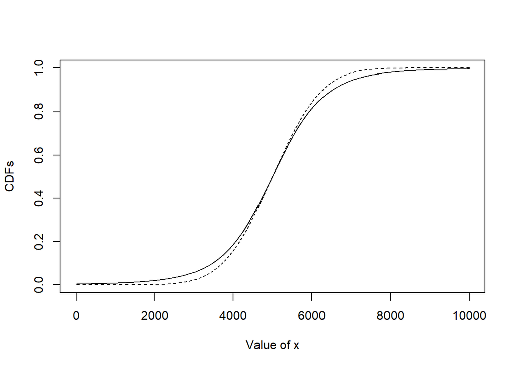

```r
x <- seq(-5, 5, length.out=10000)
cdf.t <- pt(x, df=4)
cdf.n <- pnorm(x)
plot(cdf.t, type='l', xlab='Value of x', ylab='CDFs')
lines(cdf.n, lty=2)
```

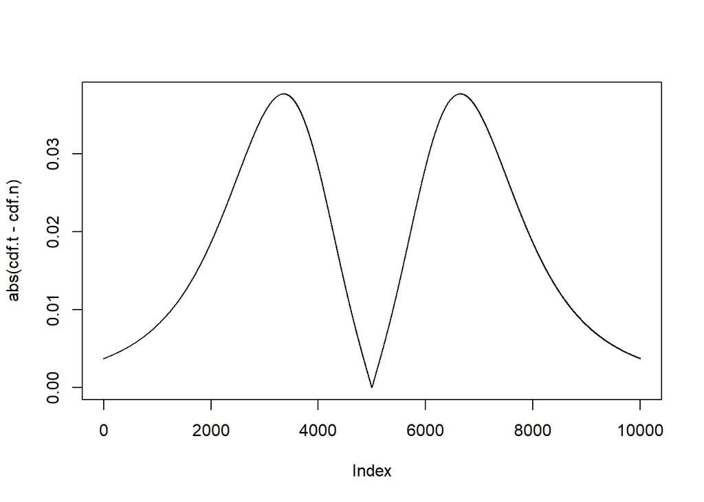

```r
plot(abs(cdf.t - cdf.n), type = 'l')
```

```r
# What is the maximum gap between the CDFs of 𝑡𝜈=4 vs 𝑁(0, 1)?
gap <- abs(cdf.n - cdf.t)
cat("Maximum gap between the CDFs of 𝑡𝜈=4 vs 𝑁(0, 1):\n")
```

```
## Maximum gap between the CDFs of 𝑡𝜈=4 vs 𝑁(0, 1):
```

```r
max(gap)
```

```
## [1] 0.03767268
```

```r
# How large does 𝜈 need for the maximum gap between the CDFs to be < 0.001?
cdf1.t <- pt(x, df=159) # after testings and trials/errors, df>=159 will make the maximum gap between the CDFs to be < 0.001.
cdf1.n <- pnorm(x)
gap1 <- abs(cdf1.n - cdf1.t)
cat("𝜈 need to be 159 for the maximum gap between the CDFs to be < 0.001: \n")
```

```
## 𝜈 need to be 159 for the maximum gap between the CDFs to be < 0.001:
```

```r
max(gap1)
```

```
## [1] 0.0009941094
```

## Use another method (for loop) to detect the 𝜈value

```r
i <- seq(1, 1000, by=1)

for(i in seq(1, 1000, by=1)) {
  x <- seq(-5, 5, length.out=10000)
  cdf1.t <- pt(x, df=i)
  cdf1.n <- pnorm(x)
  gap2 <- abs(cdf1.n - cdf1.t)
  max(gap2)
  if(max(gap2) < 0.001) {
    cat("𝜈 need to be", i, "for the maximum gap between the CDFs to be < 0.001")
    break
  }
  # print(i)
  # print(max(gap2))
  i <- i + 1
}
```

```
## 𝜈 need to be 159 for the maximum gap between the CDFs to be < 0.001
```

## Question 7

1. Toss a fair coin once.
2. If Step 1 is a head, then toss your coin 100 times and record the sequence of 1’s and 0’s with 1 for head and 0 for tail. If you are lazy, then use R’s rbinom(100, size=1, prob=0.5).
3. Otherwise, if Step 1 is a tail, then simply write down an arbitrary sequence of 1’s and 0’s of length 100 as “randomly” as possible without any help.

```r
# If it is a head
rbinom(100, size=1, prob=0.5)
```

```
##   [1] 0 1 1 0 1 0 1 0 1 0 1 1 0 0 1 1 1 1 0 1 0 1 1 0 1 0 0 1 1 0 1 0 0 0 0 0 0
##  [38] 1 0 1 1 0 0 1 1 1 0 1 0 0 1 1 0 1 1 1 1 1 0 1 1 1 1 0 0 0 0 1 1 0 0 1 0 1
##  [75] 1 0 1 1 1 0 0 1 0 1 1 1 0 1 1 1 1 0 0 1 0 0 1 1 1 1
```

```r
# If it is a tail
# creating a list
mylist <- list(1,0,0,0,0,1,1,1,1,0,0,0,1,1,1,0,0,0,0,1,1,1,1,0,0,0,0,1,1,1,1,1,0,0,0,0,0,1,1,1,1,1,1,0,0,0,0,1,1,1,1,0,0,0,1,1,1,0,0,1,1,1,0,0,0,0,1,1,1,0,0,0,0,1,1,1,1,1,1,1,0,0,0,0,1,1,1,1,0,0,0,1,1,1,1,0,0,1,1,1)
# using the length function
length(mylist)
```

```
## [1] 100
```